# التكامل الاقتصادي الخليجي — أين نقف؟

ملخص تنفيذي | مرصد الخليج لمسارات التكامل الاقتصادي

مركز الإحصاء لدول مجلس التعاون الخليجي

April 2026

## ما الذي يقيسه هذا المؤشر

طوّر مركز الإحصاء لدول مجلس التعاون الخليجي **مؤشر التكامل الاقتصادي الخليجي (GCCEII)** لقياس ومتابعة عُمق التكامل الاقتصادي بين الاقتصادات الست لدول مجلس التعاون. يدمج المؤشر بيانات التدفقات التجارية والروابط المالية وحركة العمالة والبنية التحتية والتنويع الاقتصادي والمواءمة الاقتصادية الكلية في درجة واحدة على مقياس من **0 إلى 100**، حيث تُشير الدرجات الأعلى إلى تكامل أعمق.

يغطي المؤشر الفترة من **2015 إلى 2024**، وقد تم بناؤه وفق منهجية دولية معتمدة لبناء المؤشرات المركّبة (حزمة COINr التي طوّرها مركز البحوث المشترك التابع للمفوضية الأوروبية). ويستعرض هذا الملخص النتائج الرئيسية على مستوى دول المجلس ككل.

## كيف تطور التكامل الخليجي؟

ظلّت درجة التكامل الإجمالية لدول مجلس التعاون **مستقرة نسبياً طوال الفترة بأكملها**، مع انخفاض إلى أدنى مستوياتها في عام 2020 خلال جائحة كوفيد-19 قبل أن تتعافى تدريجياً.

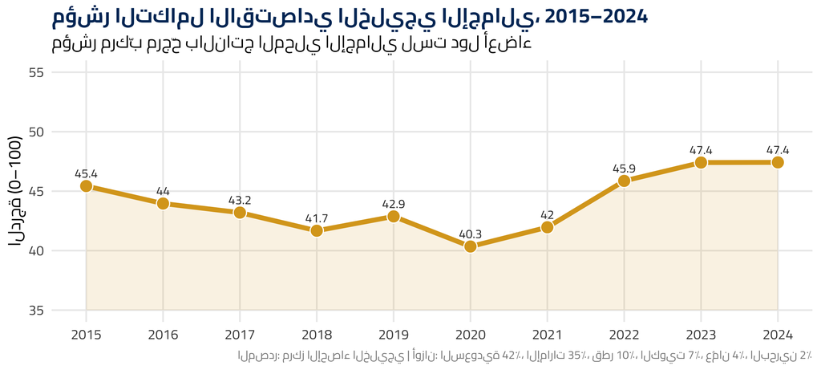

بلغت درجة التكامل الخليجي **45.4 في عام 2015** ووصلت إلى **47.4 في عام 2024** — أي بتحسّن متواضع يقارب نقطتين خلال عقد من الزمن. وقد انخفضت الدرجة إلى أدنى مستوى عند **40.3 في عام 2020** قبل أن تستعيد عافيتها تدريجياً. ورغم المبادرات التكاملية البارزة، فإن وتيرة التقدّم كانت بطيئة.

يعكس هذا المسار المستقر حقيقتين بنيويتين. أولاً، **تستحوذ المملكة العربية السعودية والإمارات معاً على أكثر من ثلاثة أرباع الناتج المحلي الإجمالي لدول المجلس**، مما يجعل المؤشر المركّب محكوماً إلى حدٍّ بعيد بأدائهما — وكلاهما يواجه سمات بنيوية (قطاعات نفط تصديرية كبيرة، وتجارة بينية خليجية محدودة) تُبقي المؤشر الإجمالي منخفضاً. ثانياً، في حين تحسّنت مجالات فردية للسياسات، لم يتقدّم أي بُعد بما يكفي لتحريك الدرجة الإجمالية إلى الأعلى بشكل حاسم.

## ما هي المجالات التي تدفع التكامل — وأيها يعيقه؟

تتكوّن الدرجة الإجمالية من ستة أبعاد. يوضّح الرسم البياني أدناه درجة كل بُعد في عام 2024.

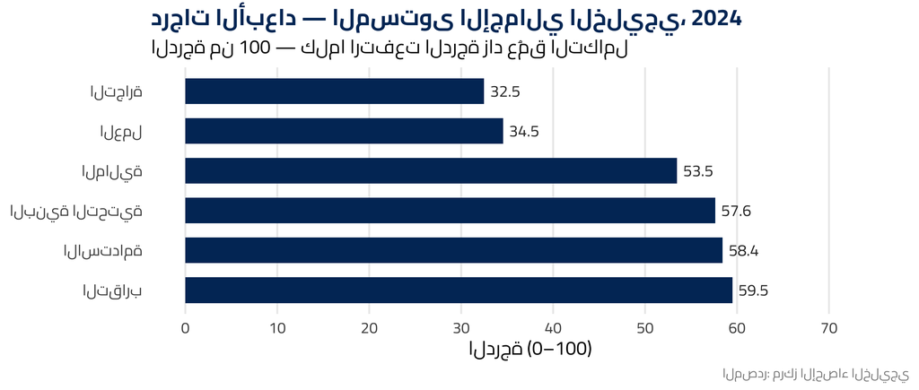

في عام 2024، يُعدّ بُعد **التقارب الاقتصادي** (المواءمة بين الاقتصادات الكلية) أعلى الأبعاد درجةً عند 59.5، ويعكس ذلك الارتباط المشترك للعملات الخليجية بالدولار الأمريكي والسياسات الاقتصادية المنسّقة. أما **التكامل التجاري فهو الأضعف** عند 32.5، ويعكس ذلك أن معظم دول المجلس لا تزال تُصدّر أساساً إلى أسواق خارج المنطقة.

يلخّص الجدول التالي أداء كل بُعد واتجاهه خلال العقد:

[output not shown]

## الفروقات بين الدول نظرة سريعة

تتباين الدول الأعضاء تبايناً ملحوظاً في مستويات تكاملها. يعرض الجدول أدناه الدرجة الإجمالية لكل دولة في عام 2024.

| الدولة | الدرجة | نقاط القوة الرئيسية | التحدي الرئيسي |
| --- | --- | --- | --- |
| البحرين | 64.3 | التكامل المالي والانفتاح التجاري | الحجم الصغير يحدّ من النطاق؛ درجات العمل متوسطة |
| الإمارات | 53.6 | درجات بنية تحتية عالية وتقارب قوي | كثافة التجارة منخفضة؛ سوق العمل مقيّد |
| قطر | 51.7 | حركة عمالة مرتفعة وتكامل مالي | درجات التجارة والاستدامة ضعيفة |
| عُمان | 46.8 | تعافي التجارة والبنية التحتية بعد 2021 | التجارة لا تزال منخفضة؛ الاستدامة غير متطوّرة |
| الكويت | 45.5 | استثمارات ضخمة في البنية التحتية، وتنويع | أدنى كثافة تجارية في الخليج؛ العمل مقيّد |
| السعودية | 44.2 | عُمق مالي وتقارب اقتصادي كلي | حركة العمالة متوسطة؛ البنية التحتية متفاوتة |

تتصدّر **البحرين** دول المجلس بأعلى درجة تكامل (64.3)، مدفوعةً بقطاعها المالي المنفتح وروابطها التجارية. أما **المملكة العربية السعودية** فقد شهدت تراجعاً ملحوظاً بين 2016 و2021 قبل أن تتعافى — ومسارها هو الأهم للمؤشر الخليجي الإجمالي نظراً لحجمها الاقتصادي. ويُعدّ تعافي **قطر** منذ اتفاق العُلا في 2021 أبرز تحسّن في السنوات الأخيرة.

## ثلاث توصيات ذات أولوية

**1. تسريع تنويع التجارة البينية الخليجية**

التجارة هي أضعف أبعاد التكامل ولم تتحرّك تقريباً خلال عقد من الزمن. لا تزال معظم الصادرات الخليجية تتجه إلى أسواق خارج المنطقة. إن تعزيز سلاسل القيمة البينية الخليجية في القطاعات غير النفطية — الصناعات التحويلية، الغذاء، خدمات التقنية — وإزالة الحواجز التنظيمية المتبقية أمام التجارة العابرة للحدود، سيكون له الأثر الأكبر على المؤشر الإجمالي. ويتطلّب ذلك تنويعاً اقتصادياً على المستوى الوطني وأُطراً تيسيرية على مستوى دول المجلس ككل.

**2. تطوير إطار موحّد لحركة العمالة الخليجية**

رغم اعتماد الخليج على ملايين العمال العابرين للحدود، تظل حركة العمالة بين الدول الأعضاء مقيّدة بنيوياً بفعل الأُطر التنظيمية المنفصلة. إن تصريح عمل خليجي موحّد، والاعتراف المتبادل بالمؤهلات المهنية، وتوحيد قواعد التأشيرات، ستُحسّن بشكل مباشر أحد أكثر أبعاد المؤشر ركوداً — وستُقدّم فوائد اقتصادية حقيقية للعمال وأصحاب العمل واقتصادات الدول الأعضاء.

**3. دعم تعميق التكامل في المملكة العربية السعودية**

تستحوذ المملكة العربية السعودية على 42٪ من الناتج المحلي الإجمالي لدول المجلس، مما يجعل درجة تكاملها المحدّد الأكبر منفرداً للمؤشر الخليجي المركّب. شهدت المملكة تراجعاً ملحوظاً في درجات تكاملها بين 2016 و2021 قبل أن تتعافى في السنوات الأخيرة. إن المبادرات الثنائية المستهدفة — وبخاصة تعميق الروابط بين أسواق رأس المال السعودية والإماراتية، وتوسيع مشاركة المملكة في التجارة البينية الخليجية — ستُحدث أثراً متناسباً كبيراً على المؤشر الإقليمي، وستُشير إلى زخم حقيقي في أجندة التكامل.

*أُعدّ من قِبل مركز الإحصاء لدول مجلس التعاون الخليجي | مرصد الخليج لمسارات التكامل الاقتصادي*  
*مصدر البيانات: خط إنتاج المؤشر المركّب GCCEII، `output/gcceii_scores.csv`*  
*للاطلاع على التقرير التحليلي الكامل مع المنهجية وملفات الدول، يُرجى زيارة لوحة مرصد الخليج.*